Skip to Main

[figure not shown]

# Midterm project

Last Checkpoint: 2 days ago

import pandas as pd

import numpy as np

import scipy.stats as st

import numpy as np

from sklearn.linear_model import LinearRegression

import statsmodels.api as sm

from sklearn.metrics import mean_squared_error,mean_absolute_error,mean_absolute_percentage_error

import matplotlib.pyplot as plt

import plotly.graph_objects as go

from warnings import filterwarnings

import seaborn as sb

filterwarnings('ignore')

# Midterm project

Congratulations! You've been hired as a data scientist at the hottest new social media startup.

Your company produces an app via which users can post short videos for anyone to view. They can also like, repost, and comment on the videos they view. The key data product is a recommendation engine that determines the order in which videos are shown to a user.

The recommendation engine has a parameter, *theta*, that affects the ordering of the videos. Recently the team of engineers that works on the recommendation engine ran it with different settings of *theta* and, for each setting, measured the amount of time users spent on the app. They have collected these measurements into a data set of 20 samples of (*theta*, *time_spent*) pairs.

Additionally, they have identified two auxiliary features (*aux1* and *aux2*) that they hypoithesize should correlate with *time_spent*. These two features are measures of time spent by users in the recent past. The engineers have not verified that the features explain *time_spent*.

(The engineers call these two features "auxiliary" because, while they might help explain *time_spent*, the engineers' ultimate interest lies in the dependence of *time_spent* on *theta*.)

Your first project at your new company is to tell the engineers which setting you think they should use for *theta*, based on the data.

# 1. Prepare the data

- Inspect the data. Identifiy and remove any suspicious or unusable samples.
- Put the samples in a data structure that you can work with.

theta = [0.03906292, 0.05119367, 0.06004468, 0.06790036, 0.19152079,

0.28298816, 0.294665 , 0.3578136 , 0.48352862, 0.53058676,

0.55175137, 0.57560289, 0.59751325, 0.6375209 , 0.65241862,

0.65633352, 0.78698546, 0.8640421 , 0.87729053, 0.94568319]

aux1 = [ 0.53983961, -1.77528229, 1.31487654, -0.47344805, -1.0922299 ,

-0.25002744, -0.9822943 , 1.03126909, 0.49133378, -0.4466466 ,

-0.80636008, 0.13126776, -1.21256024, 0.15999085, -0.75522304,

0.34989599, 0.97754176, -0.13858525, 0.10385631, 0.30059104]

aux2 = [ 0.9682053 , 0.86962384, 0.56778309, 0.46528234, -1.16537308,

-2.03599479, -1.15541329, 3.34515739, 0.12672721, -0.6941789 ,

0.55767443, 0.0991466 , 0.63792617, 0.70311068, -0.91609315,

-0.78601423, 1.1191818 , -0.98339611, 0.24452002, -0.58140974]

time_spent = [10.79768391, 10.87648065, 10.29274937, 10.78756647, 9.51844772,

9.18078781, 9.90063639, 12.84823357, 10.92743478, 9.88927608,

11.3373709 , 11.43996915, 11.88392171, -11.88135476, 11.73452467,

11.18844425, 12.19144316, 11.35294826, 12.2385441 , 11.98428985]

df = pd.DataFrame({'theta':theta,'aux1':aux1,'aux2':aux2,'time_spent':time_spent})

df.head()

|  | theta | aux1 | aux2 | time_spent |
| --- | --- | --- | --- | --- |
| 0 | 0.039063 | 0.539840 | 0.968205 | 10.797684 |
| 1 | 0.051194 | -1.775282 | 0.869624 | 10.876481 |
| 2 | 0.060045 | 1.314877 | 0.567783 | 10.292749 |
| 3 | 0.067900 | -0.473448 | 0.465282 | 10.787566 |
| 4 | 0.191521 | -1.092230 | -1.165373 | 9.518448 |

df.describe()

|  | theta | aux1 | aux2 | time_spent |
| --- | --- | --- | --- | --- |
| count | 20.000000 | 20.000000 | 20.000000 | 20.000000 |
| mean | 0.475222 | -0.126610 | 0.069323 | 9.924470 |
| std | 0.292726 | 0.818612 | 1.168883 | 5.221924 |
| min | 0.039063 | -1.775282 | -2.035995 | -11.881355 |
| 25% | 0.260121 | -0.768007 | -0.818534 | 10.194721 |
| 50% | 0.541169 | -0.017364 | 0.185624 | 11.057940 |
| 75% | 0.653397 | 0.385255 | 0.654222 | 11.771874 |
| max | 0.945683 | 1.314877 | 3.345157 | 12.848234 |

sb.heatmap(df.corr(),annot = True)

plt.show()

# Multi-collinearity present making aux1 variable insignificant

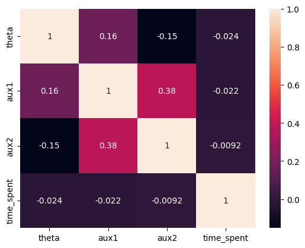

df1 = df[df.time_spent >= 0]

df1.head()

|  | theta | aux1 | aux2 | time_spent |
| --- | --- | --- | --- | --- |
| 0 | 0.039063 | 0.539840 | 0.968205 | 10.797684 |
| 1 | 0.051194 | -1.775282 | 0.869624 | 10.876481 |
| 2 | 0.060045 | 1.314877 | 0.567783 | 10.292749 |
| 3 | 0.067900 | -0.473448 | 0.465282 | 10.787566 |
| 4 | 0.191521 | -1.092230 | -1.165373 | 9.518448 |

# 2. Build a model

Write functions to run a regression, calculate the regression statistics listed below, and print a report.

- B (regressor coefficients plus one for an intercept, if appropriate)
- R2
- RSS
- RegSS
- TSS
- t statistic for each regressor coefficient

I found it useful to decompose the problem into three functions: `regress_calc()`, `regress_tstat()`, and `regress_report()`. You may write it however you see fit.

You may include either, both, or neither of *aux1* and *aux2* in your final model. Experiment. What works best? Justify your decision.

X = df1.iloc[:,:3]

X1 = df1.iloc[:,:2]

X2 = df1[['theta','aux2']]

X3 = df1[['theta']]

X4 = sm.add_constant(X3)

X5 = sm.add_constant(X)

X6 = sm.add_constant(X1)

X7 = sm.add_constant(X2)

y = df1.time_spent

def regress_tstat(model):

return pd.DataFrame({'t-statistic':model.tvalues,'pvalues':model.pvalues})

def get_coefficients(model):

return pd.DataFrame(model.params,columns=['Coefficients'])

def regress_calc(M,x,y,m=''):

y_pred = M.predict(x)

SST = np.sum((y-np.mean(y))**2) #Total Sum of Squares SST = sum((y-y_mean)**2)

SSR = M.rsquared*SST # R2 = SSR/SST hence SSR = R2 * SST

SSE = SST- SSR

return pd.DataFrame({'Model':[m],

'R2':[M.rsquared],

'Adj_R2':[M.rsquared_adj],

'SSE':[SSE],

'SSR':[SSR],

'SST':[SST],

'MSE':[mean_squared_error(y,y_pred)],

'RMSE':[np.sqrt(mean_squared_error(y,y_pred))],

'MAE':[mean_absolute_error(y,y_pred)],

'MAPE':[mean_absolute_percentage_error(y,y_pred)]})

### Full Model without Constant

model = sm.OLS(y,X).fit()

model.summary()

OLS Regression Results

| Dep. Variable: | time_spent | R-squared (uncentered): | 0.803 |
| --- | --- | --- | --- |
| Model: | OLS | Adj. R-squared (uncentered): | 0.766 |
| Method: | Least Squares | F-statistic: | 21.68 |
| Date: | Wed, 06 Mar 2024 | Prob (F-statistic): | 7.00e-06 |
| Time: | 13:17:00 | Log-Likelihood: | -57.304 |
| No. Observations: | 19 | AIC: | 120.6 |
| Df Residuals: | 16 | BIC: | 123.4 |
| Df Model: | 3 |  |  |
| Covariance Type: | nonrobust |  |  |

|  | coef | std err | t | P>\|t\| | [0.025 | 0.975] |
| --- | --- | --- | --- | --- | --- | --- |
| theta | 17.6885 | 2.253 | 7.850 | 0.000 | 12.912 | 22.465 |
| aux1 | -2.1228 | 1.598 | -1.328 | 0.203 | -5.511 | 1.266 |
| aux2 | 1.9014 | 1.141 | 1.666 | 0.115 | -0.518 | 4.320 |

| Omnibus: | 1.684 | Durbin-Watson: | 0.323 |
| --- | --- | --- | --- |
| Prob(Omnibus): | 0.431 | Jarque-Bera (JB): | 1.188 |
| Skew: | 0.367 | Prob(JB): | 0.552 |
| Kurtosis: | 2.020 | Cond. No. | 2.23 |

Notes:  
[1] R² is computed without centering (uncentered) since the model does not contain a constant.  
[2] Standard Errors assume that the covariance matrix of the errors is correctly specified.

get_coefficients(model)

|  | Coefficients |
| --- | --- |
| theta | 17.688544 |
| aux1 | -2.122787 |
| aux2 | 1.901389 |

regress_tstat(model)

|  | t-statistic | pvalues |
| --- | --- | --- |
| theta | 7.849837 | 7.084696e-07 |
| aux1 | -1.328086 | 2.027848e-01 |
| aux2 | 1.666329 | 1.151011e-01 |

Full = regress_calc(model,X,y,m='Full Model without constant')

Full

|  | Model | R2 | Adj_R2 | SSE | SSR | SST | MSE | RMSE | MAE | MAPE |
| --- | --- | --- | --- | --- | --- | --- | --- | --- | --- | --- |
| 0 | Full Model without constant | 0.802549 | 0.765527 | 3.471452 | 14.109922 | 17.581373 | 24.388642 | 4.938486 | 3.956237 | 0.372579 |

### Model with theta and aux1

model1 = sm.OLS(y,X1).fit()

model1.summary()

OLS Regression Results

| Dep. Variable: | time_spent | R-squared (uncentered): | 0.768 |
| --- | --- | --- | --- |
| Model: | OLS | Adj. R-squared (uncentered): | 0.741 |
| Method: | Least Squares | F-statistic: | 28.18 |
| Date: | Wed, 06 Mar 2024 | Prob (F-statistic): | 4.00e-06 |
| Time: | 13:17:00 | Log-Likelihood: | -58.824 |
| No. Observations: | 19 | AIC: | 121.6 |
| Df Residuals: | 17 | BIC: | 123.5 |
| Df Model: | 2 |  |  |
| Covariance Type: | nonrobust |  |  |

|  | coef | std err | t | P>\|t\| | [0.025 | 0.975] |
| --- | --- | --- | --- | --- | --- | --- |
| theta | 17.5237 | 2.366 | 7.407 | 0.000 | 12.532 | 22.515 |
| aux1 | -1.1765 | 1.570 | -0.749 | 0.464 | -4.489 | 2.136 |

| Omnibus: | 1.597 | Durbin-Watson: | 0.195 |
| --- | --- | --- | --- |
| Prob(Omnibus): | 0.450 | Jarque-Bera (JB): | 1.116 |
| Skew: | 0.330 | Prob(JB): | 0.572 |
| Kurtosis: | 2.013 | Cond. No. | 1.51 |

Notes:  
[1] R² is computed without centering (uncentered) since the model does not contain a constant.  
[2] Standard Errors assume that the covariance matrix of the errors is correctly specified.

get_coefficients(model1)

|  | Coefficients |
| --- | --- |
| theta | 17.523653 |
| aux1 | -1.176491 |

regress_tstat(model1)

|  | t-statistic | pvalues |
| --- | --- | --- |
| theta | 7.406751 | 0.000001 |
| aux1 | -0.749249 | 0.463950 |

Model_with_theta_aux1 = regress_calc(model1,X1,y,m = 'Model with theta and aux1')

Model_with_theta_aux1

|  | Model | R2 | Adj_R2 | SSE | SSR | SST | MSE | RMSE | MAE | MAPE |
| --- | --- | --- | --- | --- | --- | --- | --- | --- | --- | --- |
| 0 | Model with theta and aux1 | 0.768284 | 0.741023 | 4.07389 | 13.507483 | 17.581373 | 28.621065 | 5.349866 | 4.01667 | 0.370482 |

### Model with theta and aux2

model2 = sm.OLS(y,X2).fit()

model2.summary()

OLS Regression Results

| Dep. Variable: | time_spent | R-squared (uncentered): | 0.781 |
| --- | --- | --- | --- |
| Model: | OLS | Adj. R-squared (uncentered): | 0.755 |
| Method: | Least Squares | F-statistic: | 30.27 |
| Date: | Wed, 06 Mar 2024 | Prob (F-statistic): | 2.50e-06 |
| Time: | 13:17:00 | Log-Likelihood: | -58.297 |
| No. Observations: | 19 | AIC: | 120.6 |
| Df Residuals: | 17 | BIC: | 122.5 |
| Df Model: | 2 |  |  |
| Covariance Type: | nonrobust |  |  |

|  | coef | std err | t | P>\|t\| | [0.025 | 0.975] |
| --- | --- | --- | --- | --- | --- | --- |
| theta | 17.8212 | 2.301 | 7.744 | 0.000 | 12.966 | 22.676 |
| aux2 | 1.3630 | 1.090 | 1.250 | 0.228 | -0.937 | 3.663 |

| Omnibus: | 3.936 | Durbin-Watson: | 0.081 |
| --- | --- | --- | --- |
| Prob(Omnibus): | 0.140 | Jarque-Bera (JB): | 1.375 |
| Skew: | 0.073 | Prob(JB): | 0.503 |
| Kurtosis: | 1.690 | Cond. No. | 2.12 |

Notes:  
[1] R² is computed without centering (uncentered) since the model does not contain a constant.  
[2] Standard Errors assume that the covariance matrix of the errors is correctly specified.

get_coefficients(model2)

|  | Coefficients |
| --- | --- |
| theta | 17.821177 |
| aux2 | 1.362967 |

regress_tstat(model2)

|  | t-statistic | pvalues |
| --- | --- | --- |
| theta | 7.744409 | 5.663004e-07 |
| aux2 | 1.250068 | 2.282099e-01 |

Model_with_theta_aux2 = regress_calc(model2,X2,y,m = 'Model with theta and aux2')

Model_with_theta_aux2

|  | Model | R2 | Adj_R2 | SSE | SSR | SST | MSE | RMSE | MAE | MAPE |
| --- | --- | --- | --- | --- | --- | --- | --- | --- | --- | --- |
| 0 | Model with theta and aux2 | 0.780783 | 0.754993 | 3.854139 | 13.727235 | 17.581373 | 27.077205 | 5.203576 | 4.166276 | 0.39246 |

### Model with theta

model3 = sm.OLS(y,X3).fit()

model3.summary()

OLS Regression Results

| Dep. Variable: | time_spent | R-squared (uncentered): | 0.761 |
| --- | --- | --- | --- |
| Model: | OLS | Adj. R-squared (uncentered): | 0.747 |
| Method: | Least Squares | F-statistic: | 57.20 |
| Date: | Wed, 06 Mar 2024 | Prob (F-statistic): | 5.40e-07 |
| Time: | 13:17:00 | Log-Likelihood: | -59.133 |
| No. Observations: | 19 | AIC: | 120.3 |
| Df Residuals: | 18 | BIC: | 121.2 |
| Df Model: | 1 |  |  |
| Covariance Type: | nonrobust |  |  |

|  | coef | std err | t | P>\|t\| | [0.025 | 0.975] |
| --- | --- | --- | --- | --- | --- | --- |
| theta | 17.6374 | 2.332 | 7.563 | 0.000 | 12.738 | 22.537 |

| Omnibus: | 1.865 | Durbin-Watson: | 0.094 |
| --- | --- | --- | --- |
| Prob(Omnibus): | 0.393 | Jarque-Bera (JB): | 1.027 |
| Skew: | 0.152 | Prob(JB): | 0.598 |
| Kurtosis: | 1.902 | Cond. No. | 1.00 |

Notes:  
[1] R² is computed without centering (uncentered) since the model does not contain a constant.  
[2] Standard Errors assume that the covariance matrix of the errors is correctly specified.

get_coefficients(model3)

|  | Coefficients |
| --- | --- |
| theta | 17.637397 |

regress_tstat(model3)

|  | t-statistic | pvalues |
| --- | --- | --- |
| theta | 7.562938 | 5.403488e-07 |

Model_with_theta = regress_calc(model3,X3,y,m = 'Model with theta')

Model_with_theta

|  | Model | R2 | Adj_R2 | SSE | SSR | SST | MSE | RMSE | MAE | MAPE |
| --- | --- | --- | --- | --- | --- | --- | --- | --- | --- | --- |
| 0 | Model with theta | 0.760632 | 0.747334 | 4.208418 | 13.372955 | 17.581373 | 29.566189 | 5.43748 | 4.303507 | 0.397699 |

### Model with constant and theta

model4 = sm.OLS(y,X4).fit()

model4.summary()

OLS Regression Results

| Dep. Variable: | time_spent | R-squared: | 0.327 |
| --- | --- | --- | --- |
| Model: | OLS | Adj. R-squared: | 0.288 |
| Method: | Least Squares | F-statistic: | 8.266 |
| Date: | Wed, 06 Mar 2024 | Prob (F-statistic): | 0.0105 |
| Time: | 13:17:01 | Log-Likelihood: | -22.458 |
| No. Observations: | 19 | AIC: | 48.92 |
| Df Residuals: | 17 | BIC: | 50.81 |
| Df Model: | 1 |  |  |
| Covariance Type: | nonrobust |  |  |

|  | coef | std err | t | P>\|t\| | [0.025 | 0.975] |
| --- | --- | --- | --- | --- | --- | --- |
| const | 10.1874 | 0.362 | 28.112 | 0.000 | 9.423 | 10.952 |
| theta | 1.8958 | 0.659 | 2.875 | 0.011 | 0.505 | 3.287 |

| Omnibus: | 1.463 | Durbin-Watson: | 1.900 |
| --- | --- | --- | --- |
| Prob(Omnibus): | 0.481 | Jarque-Bera (JB): | 0.274 |
| Skew: | 0.101 | Prob(JB): | 0.872 |
| Kurtosis: | 3.553 | Cond. No. | 4.25 |

Notes:  
[1] Standard Errors assume that the covariance matrix of the errors is correctly specified.

get_coefficients(model4)

|  | Coefficients |
| --- | --- |
| const | 10.187390 |
| theta | 1.895847 |

regress_tstat(model4)

|  | t-statistic | pvalues |
| --- | --- | --- |
| const | 28.112358 | 1.080093e-15 |
| theta | 2.875114 | 1.050165e-02 |

Model_with_const_theta = regress_calc(model4,X4,y,m = 'Model with const and theta')

Model_with_theta

|  | Model | R2 | Adj_R2 | SSE | SSR | SST | MSE | RMSE | MAE | MAPE |
| --- | --- | --- | --- | --- | --- | --- | --- | --- | --- | --- |
| 0 | Model with theta | 0.760632 | 0.747334 | 4.208418 | 13.372955 | 17.581373 | 29.566189 | 5.43748 | 4.303507 | 0.397699 |

### Model with constant theta aux1 and aux2

model5 = sm.OLS(y,X5).fit()

model5.summary()

OLS Regression Results

| Dep. Variable: | time_spent | R-squared: | 0.888 |
| --- | --- | --- | --- |
| Model: | OLS | Adj. R-squared: | 0.866 |
| Method: | Least Squares | F-statistic: | 39.71 |
| Date: | Wed, 06 Mar 2024 | Prob (F-statistic): | 2.25e-07 |
| Time: | 13:17:01 | Log-Likelihood: | -5.4095 |
| No. Observations: | 19 | AIC: | 18.82 |
| Df Residuals: | 15 | BIC: | 22.60 |
| Df Model: | 3 |  |  |
| Covariance Type: | nonrobust |  |  |

|  | coef | std err | t | P>\|t\| | [0.025 | 0.975] |
| --- | --- | --- | --- | --- | --- | --- |
| const | 9.9201 | 0.167 | 59.334 | 0.000 | 9.564 | 10.276 |
| theta | 2.3877 | 0.299 | 7.982 | 0.000 | 1.750 | 3.025 |
| aux1 | -0.1000 | 0.113 | -0.887 | 0.389 | -0.340 | 0.140 |
| aux2 | 0.6561 | 0.080 | 8.245 | 0.000 | 0.487 | 0.826 |

| Omnibus: | 5.471 | Durbin-Watson: | 1.388 |
| --- | --- | --- | --- |
| Prob(Omnibus): | 0.065 | Jarque-Bera (JB): | 3.845 |
| Skew: | -0.333 | Prob(JB): | 0.146 |
| Kurtosis: | 5.101 | Cond. No. | 4.96 |

Notes:  
[1] Standard Errors assume that the covariance matrix of the errors is correctly specified.

get_coefficients(model5)

|  | Coefficients |
| --- | --- |
| const | 9.920095 |
| theta | 2.387676 |
| aux1 | -0.100006 |
| aux2 | 0.656137 |

regress_tstat(model5)

|  | t-statistic | pvalues |
| --- | --- | --- |
| const | 59.334340 | 3.271299e-19 |
| theta | 7.982085 | 8.851896e-07 |
| aux1 | -0.886578 | 3.892997e-01 |
| aux2 | 8.245170 | 5.925766e-07 |

Model_with_const_theta_aux1_aux2 = regress_calc(model5,X5,y,m = 'Model with const theta aux1 and aux2')

Model_with_const_theta_aux1_aux2

|  | Model | R2 | Adj_R2 | SSE | SSR | SST | MSE | RMSE | MAE | MAPE |
| --- | --- | --- | --- | --- | --- | --- | --- | --- | --- | --- |
| 0 | Model with const theta aux1 and aux2 | 0.88818 | 0.865816 | 1.965956 | 15.615417 | 17.581373 | 0.103471 | 0.32167 | 0.217073 | 0.01999 |

### Model with constant theta and aux1

model6 = sm.OLS(y,X6).fit()

model6.summary()

OLS Regression Results

| Dep. Variable: | time_spent | R-squared: | 0.381 |
| --- | --- | --- | --- |
| Model: | OLS | Adj. R-squared: | 0.304 |
| Method: | Least Squares | F-statistic: | 4.932 |
| Date: | Wed, 06 Mar 2024 | Prob (F-statistic): | 0.0214 |
| Time: | 13:17:01 | Log-Likelihood: | -21.660 |
| No. Observations: | 19 | AIC: | 49.32 |
| Df Residuals: | 16 | BIC: | 52.15 |
| Df Model: | 2 |  |  |
| Covariance Type: | nonrobust |  |  |

|  | coef | std err | t | P>\|t\| | [0.025 | 0.975] |
| --- | --- | --- | --- | --- | --- | --- |
| const | 10.2836 | 0.367 | 28.000 | 0.000 | 9.505 | 11.062 |
| theta | 1.7740 | 0.660 | 2.689 | 0.016 | 0.375 | 3.173 |
| aux1 | 0.2780 | 0.235 | 1.184 | 0.254 | -0.220 | 0.776 |

| Omnibus: | 0.137 | Durbin-Watson: | 2.021 |
| --- | --- | --- | --- |
| Prob(Omnibus): | 0.934 | Jarque-Bera (JB): | 0.032 |
| Skew: | 0.006 | Prob(JB): | 0.984 |
| Kurtosis: | 2.800 | Cond. No. | 4.38 |

Notes:  
[1] Standard Errors assume that the covariance matrix of the errors is correctly specified.

get_coefficients(model6)

|  | Coefficients |
| --- | --- |
| const | 10.283646 |
| theta | 1.773987 |
| aux1 | 0.277963 |

regress_tstat(model6)

|  | t-statistic | pvalues |
| --- | --- | --- |
| const | 27.999956 | 5.072769e-15 |
| theta | 2.688659 | 1.614248e-02 |
| aux1 | 1.184239 | 2.536133e-01 |

Model_with_const_theta_aux1 = regress_calc(model6,X6,y,m = 'Model with const theta and aux1')

Model_with_const_theta_aux1

|  | Model | R2 | Adj_R2 | SSE | SSR | SST | MSE | RMSE | MAE | MAPE |
| --- | --- | --- | --- | --- | --- | --- | --- | --- | --- | --- |
| 0 | Model with const theta and aux1 | 0.381389 | 0.304062 | 10.876038 | 6.705335 | 17.581373 | 0.572423 | 0.756586 | 0.614386 | 0.057124 |

### Model with constant theta and aux2

model7 = sm.OLS(y,X7).fit()

model7.summary()

OLS Regression Results

| Dep. Variable: | time_spent | R-squared: | 0.882 |
| --- | --- | --- | --- |
| Model: | OLS | Adj. R-squared: | 0.868 |
| Method: | Least Squares | F-statistic: | 59.98 |
| Date: | Wed, 06 Mar 2024 | Prob (F-statistic): | 3.68e-08 |
| Time: | 13:17:01 | Log-Likelihood: | -5.8947 |
| No. Observations: | 19 | AIC: | 17.79 |
| Df Residuals: | 16 | BIC: | 20.62 |
| Df Model: | 2 |  |  |
| Covariance Type: | nonrobust |  |  |

|  | coef | std err | t | P>\|t\| | [0.025 | 0.975] |
| --- | --- | --- | --- | --- | --- | --- |
| const | 9.9649 | 0.158 | 62.949 | 0.000 | 9.629 | 10.300 |
| theta | 2.3243 | 0.289 | 8.056 | 0.000 | 1.713 | 2.936 |
| aux2 | 0.6275 | 0.072 | 8.688 | 0.000 | 0.474 | 0.781 |

| Omnibus: | 4.490 | Durbin-Watson: | 1.430 |
| --- | --- | --- | --- |
| Prob(Omnibus): | 0.106 | Jarque-Bera (JB): | 2.812 |
| Skew: | -0.125 | Prob(JB): | 0.245 |
| Kurtosis: | 4.868 | Cond. No. | 4.52 |

Notes:  
[1] Standard Errors assume that the covariance matrix of the errors is correctly specified.

get_coefficients(model7)

|  | Coefficients |
| --- | --- |
| const | 9.964893 |
| theta | 2.324257 |
| aux2 | 0.627465 |

regress_tstat(model7)

|  | t-statistic | pvalues |
| --- | --- | --- |
| const | 62.948601 | 1.346041e-20 |
| theta | 8.056302 | 5.062555e-07 |
| aux2 | 8.687911 | 1.871613e-07 |

Model_with_const_theta_aux2 = regress_calc(model7,X7,y,m = 'Model with const theta and aux2')

Model_with_const_theta_aux2

|  | Model | R2 | Adj_R2 | SSE | SSR | SST | MSE | RMSE | MAE | MAPE |
| --- | --- | --- | --- | --- | --- | --- | --- | --- | --- | --- |
| 0 | Model with const theta and aux2 | 0.88232 | 0.86761 | 2.068975 | 15.512399 | 17.581373 | 0.108893 | 0.32999 | 0.236424 | 0.021725 |

## Final Results

Results = pd.concat([Full,Model_with_theta_aux1,Model_with_theta_aux2,Model_with_theta,Model_with_const_theta,Model_with_const_theta_aux1_aux2,

Model_with_const_theta_aux1,Model_with_const_theta_aux2],ignore_index=True)

Results

|  | Model | R2 | Adj_R2 | SSE | SSR | SST | MSE | RMSE | MAE | MAPE |
| --- | --- | --- | --- | --- | --- | --- | --- | --- | --- | --- |
| 0 | Full Model without constant | 0.802549 | 0.765527 | 3.471452 | 14.109922 | 17.581373 | 24.388642 | 4.938486 | 3.956237 | 0.372579 |
| 1 | Model with theta and aux1 | 0.768284 | 0.741023 | 4.073890 | 13.507483 | 17.581373 | 28.621065 | 5.349866 | 4.016670 | 0.370482 |
| 2 | Model with theta and aux2 | 0.780783 | 0.754993 | 3.854139 | 13.727235 | 17.581373 | 27.077205 | 5.203576 | 4.166276 | 0.392460 |
| 3 | Model with theta | 0.760632 | 0.747334 | 4.208418 | 13.372955 | 17.581373 | 29.566189 | 5.437480 | 4.303507 | 0.397699 |
| 4 | Model with const and theta | 0.327166 | 0.287588 | 11.829337 | 5.752036 | 17.581373 | 0.622597 | 0.789048 | 0.592156 | 0.055126 |
| 5 | Model with const theta aux1 and aux2 | 0.888180 | 0.865816 | 1.965956 | 15.615417 | 17.581373 | 0.103471 | 0.321670 | 0.217073 | 0.019990 |
| 6 | Model with const theta and aux1 | 0.381389 | 0.304062 | 10.876038 | 6.705335 | 17.581373 | 0.572423 | 0.756586 | 0.614386 | 0.057124 |
| 7 | Model with const theta and aux2 | 0.882320 | 0.867610 | 2.068975 | 15.512399 | 17.581373 | 0.108893 | 0.329990 | 0.236424 | 0.021725 |

models = [model,model1,model2,model3,model4,model5,model6,model7]

x = [X,X1,X2,X3,X4,X5,X6,X7]

m= Results.Model

fig,ax = plt.subplots(nrows = 4,ncols = 2,figsize = [18,30])

for i,j,k,l in zip(models,x,ax.flatten(),m):

y_pred = i.predict(j)

sb.scatterplot(x=j.theta,y=y,ax = k,label='Observed')

sb.scatterplot(x=j.theta,y=y_pred,ax=k,label='Predicted')

k.set_title(f'Model: {l}')

plt.show()

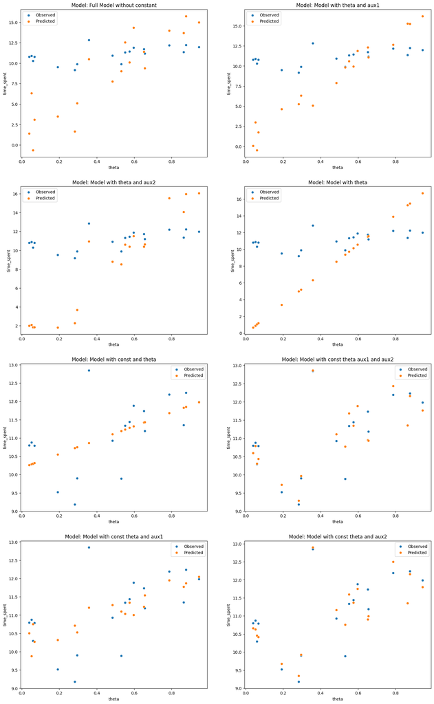

Results.sort_values(by = 'RMSE',ascending=True)

|  | Model | R2 | Adj_R2 | SSE | SSR | SST | MSE | RMSE | MAE | MAPE |
| --- | --- | --- | --- | --- | --- | --- | --- | --- | --- | --- |
| 5 | Model with const theta aux1 and aux2 | 0.888180 | 0.865816 | 1.965956 | 15.615417 | 17.581373 | 0.103471 | 0.321670 | 0.217073 | 0.019990 |
| 7 | Model with const theta and aux2 | 0.882320 | 0.867610 | 2.068975 | 15.512399 | 17.581373 | 0.108893 | 0.329990 | 0.236424 | 0.021725 |
| 6 | Model with const theta and aux1 | 0.381389 | 0.304062 | 10.876038 | 6.705335 | 17.581373 | 0.572423 | 0.756586 | 0.614386 | 0.057124 |
| 4 | Model with const and theta | 0.327166 | 0.287588 | 11.829337 | 5.752036 | 17.581373 | 0.622597 | 0.789048 | 0.592156 | 0.055126 |
| 0 | Full Model without constant | 0.802549 | 0.765527 | 3.471452 | 14.109922 | 17.581373 | 24.388642 | 4.938486 | 3.956237 | 0.372579 |
| 2 | Model with theta and aux2 | 0.780783 | 0.754993 | 3.854139 | 13.727235 | 17.581373 | 27.077205 | 5.203576 | 4.166276 | 0.392460 |
| 1 | Model with theta and aux1 | 0.768284 | 0.741023 | 4.073890 | 13.507483 | 17.581373 | 28.621065 | 5.349866 | 4.016670 | 0.370482 |
| 3 | Model with theta | 0.760632 | 0.747334 | 4.208418 | 13.372955 | 17.581373 | 29.566189 | 5.437480 | 4.303507 | 0.397699 |

### From the results we can see that model with intercept fit with all the independent variables has the least error of all the models but has aux1 variable with pvalue of t statistic >0.05 making it a insignificant variable hence we can select the model with intercept, theta and aux2 which has all the significant variables and prob(f-statistic) close to zero.

### Drawbacks of the Model:

- The dataset is too small
- Overfitting is present hence the error too small for the dataset

# 3. Propose a setting for *theta*

Now that you have a model built, you should be able to plot estimated *time_spent* vs. *theta* over a reasonable range of *theta*. By inspecting that plot -- and knowning that the company wants to maximize the time users spend on the app -- which value of *theta* would you propose the engineers use? Explain how the data and your model support your decision.

The engineer's have capacity to take another set of measurements. Which settings of *theta* do you suggest they measure? Why?

y_pred = model7.predict(X7)

fig = go.Figure()

fig.add_trace(go.Scatter(x=X7.theta, y=y_pred, mode='markers', name='time_spent'))

fig.update_layout(

title='estimated time_spent vs theta',

xaxis_title='Theta',

yaxis_title='Predicted y'

)

fig.show()

[interactive chart not shown]

### From the plot We can see that the time spent is high i.e 12.89551 for theta of value 0.3578136 hence I choose the value of 0.3578136 to increase the time spent by the users

## 4. Experiment or observation?

Is this data set experimental or observational? Explain clearly. Consider how the effect of *theta* on *time_spent* differs from the effect of *aux1* or *aux2*.

### The Dataset is Experimental data as the engineers ran the recommendation engine with different settings of theta and they measured the amount of time users spent on the app for each setting of theta. This suggests that the engineers manipulated the parameter theta (the independent variable) to observe its effect on the amount of time users spent on the app (the dependent variable). TThe data collection process involves controlled experiments where the engineers deliberately varied theta and observed the corresponding changes in time_spent